# WINE ANALYSIS by JAN KIERZYK

In this report I will analyse a data set of almost 5000 white wines with their quality scores and attributes.

# Univariate Plots Section

```
##  fixed.acidity    volatile.acidity  citric.acid     residual.sugar
##  Min.   : 3.800   Min.   :0.0800   Min.   :0.0000   Min.   : 0.600
##  1st Qu.: 6.300   1st Qu.:0.2100   1st Qu.:0.2700   1st Qu.: 1.700
##  Median : 6.800   Median :0.2600   Median :0.3200   Median : 5.200
##  Mean   : 6.855   Mean   :0.2782   Mean   :0.3342   Mean   : 6.391
##  3rd Qu.: 7.300   3rd Qu.:0.3200   3rd Qu.:0.3900   3rd Qu.: 9.900
##  Max.   :14.200   Max.   :1.1000   Max.   :1.6600   Max.   :65.800
##    chlorides       free.sulfur.dioxide total.sulfur.dioxide
##  Min.   :0.00900   Min.   :  2.00      Min.   :  9.0
##  1st Qu.:0.03600   1st Qu.: 23.00      1st Qu.:108.0
##  Median :0.04300   Median : 34.00      Median :134.0
##  Mean   :0.04577   Mean   : 35.31      Mean   :138.4
##  3rd Qu.:0.05000   3rd Qu.: 46.00      3rd Qu.:167.0
##  Max.   :0.34600   Max.   :289.00      Max.   :440.0
##     density             pH          sulphates         alcohol
##  Min.   :0.9871   Min.   :2.720   Min.   :0.2200   Min.   : 8.00
##  1st Qu.:0.9917   1st Qu.:3.090   1st Qu.:0.4100   1st Qu.: 9.50
##  Median :0.9937   Median :3.180   Median :0.4700   Median :10.40
##  Mean   :0.9940   Mean   :3.188   Mean   :0.4898   Mean   :10.51
##  3rd Qu.:0.9961   3rd Qu.:3.280   3rd Qu.:0.5500   3rd Qu.:11.40
##  Max.   :1.0390   Max.   :3.820   Max.   :1.0800   Max.   :14.20
##     quality
##  Min.   :3.000
##  1st Qu.:5.000
##  Median :6.000
##  Mean   :5.878
##  3rd Qu.:6.000
##  Max.   :9.000
```

This summary shows the range of each attribute and their statistics. For example, pH of tested white wines is between 2.72 and 3.82 with mean of 3.19

```
## [1] 4898   12
```

```
## 'data.frame':    4898 obs. of  12 variables:
##  $ fixed.acidity       : num  7 6.3 8.1 7.2 7.2 8.1 6.2 7 6.3 8.1 ...
##  $ volatile.acidity    : num  0.27 0.3 0.28 0.23 0.23 0.28 0.32 0.27 0.3 0.22 ...
##  $ citric.acid         : num  0.36 0.34 0.4 0.32 0.32 0.4 0.16 0.36 0.34 0.43 ...
##  $ residual.sugar      : num  20.7 1.6 6.9 8.5 8.5 6.9 7 20.7 1.6 1.5 ...
##  $ chlorides           : num  0.045 0.049 0.05 0.058 0.058 0.05 0.045 0.045 0.049 0.044 ...
##  $ free.sulfur.dioxide : num  45 14 30 47 47 30 30 45 14 28 ...
##  $ total.sulfur.dioxide: num  170 132 97 186 186 97 136 170 132 129 ...
##  $ density             : num  1.001 0.994 0.995 0.996 0.996 ...
##  $ pH                  : num  3 3.3 3.26 3.19 3.19 3.26 3.18 3 3.3 3.22 ...
##  $ sulphates           : num  0.45 0.49 0.44 0.4 0.4 0.44 0.47 0.45 0.49 0.45 ...
##  $ alcohol             : num  8.8 9.5 10.1 9.9 9.9 10.1 9.6 8.8 9.5 11 ...
##  $ quality             : int  6 6 6 6 6 6 6 6 6 6 ...
```

Almost all columns are numeric with except for quality that’s an integer.

```
##   fixed.acidity volatile.acidity citric.acid residual.sugar chlorides
## 1           7.0             0.27        0.36           20.7     0.045
## 2           6.3             0.30        0.34            1.6     0.049
## 3           8.1             0.28        0.40            6.9     0.050
## 4           7.2             0.23        0.32            8.5     0.058
## 5           7.2             0.23        0.32            8.5     0.058
## 6           8.1             0.28        0.40            6.9     0.050
##   free.sulfur.dioxide total.sulfur.dioxide density   pH sulphates alcohol
## 1                  45                  170  1.0010 3.00      0.45     8.8
## 2                  14                  132  0.9940 3.30      0.49     9.5
## 3                  30                   97  0.9951 3.26      0.44    10.1
## 4                  47                  186  0.9956 3.19      0.40     9.9
## 5                  47                  186  0.9956 3.19      0.40     9.9
## 6                  30                   97  0.9951 3.26      0.44    10.1
##   quality
## 1       6
## 2       6
## 3       6
## 4       6
## 5       6
## 6       6
```

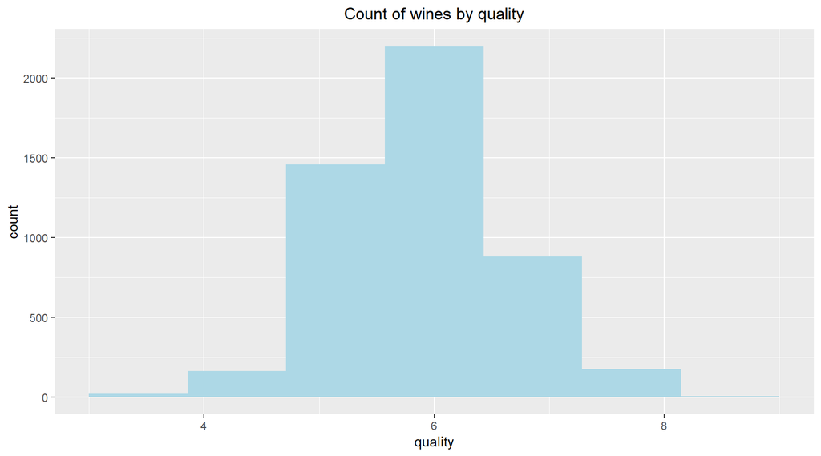

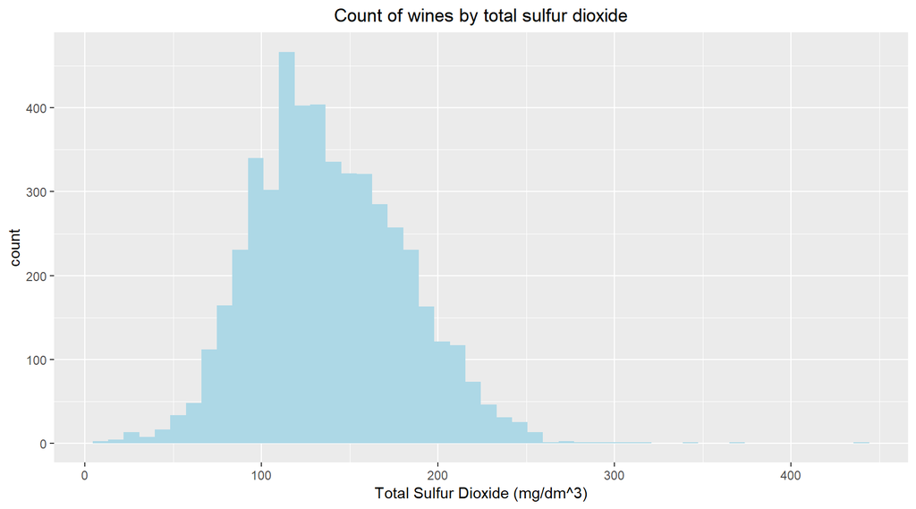

With the bin size increased to 50 we see that the total sulfur dioxide presents a normal distribution. It’s worth investigating if quality changes with the increase of alcohol percentage.

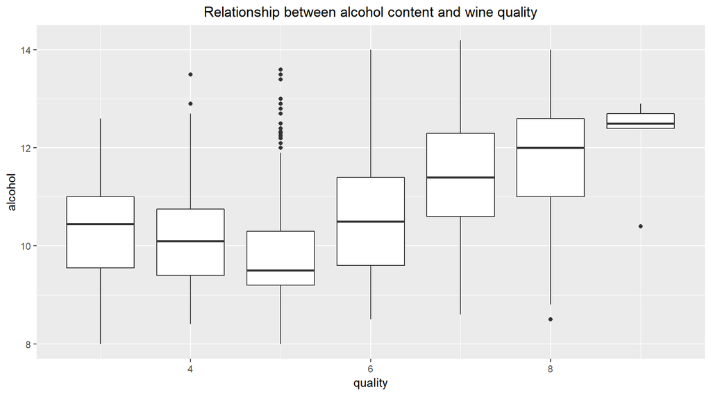

The boxplots show that worst rates wines have quite high alcohol percentage, then with increase of quality, the alcohol decreases to rise again and reach over 12% for wines rated 8 and more.

```
## $`3`
##    Min. 1st Qu.  Median    Mean 3rd Qu.    Max.
##    8.00    9.55   10.45   10.35   11.00   12.60
##
## $`4`
##    Min. 1st Qu.  Median    Mean 3rd Qu.    Max.
##    8.40    9.40   10.10   10.15   10.75   13.50
##
## $`5`
##    Min. 1st Qu.  Median    Mean 3rd Qu.    Max.
##   8.000   9.200   9.500   9.809  10.300  13.600
##
## $`6`
##    Min. 1st Qu.  Median    Mean 3rd Qu.    Max.
##    8.50    9.60   10.50   10.58   11.40   14.00
##
## $`7`
##    Min. 1st Qu.  Median    Mean 3rd Qu.    Max.
##    8.60   10.60   11.40   11.37   12.30   14.20
##
## $`8`
##    Min. 1st Qu.  Median    Mean 3rd Qu.    Max.
##    8.50   11.00   12.00   11.64   12.60   14.00
##
## $`9`
##    Min. 1st Qu.  Median    Mean 3rd Qu.    Max.
##   10.40   12.40   12.50   12.18   12.70   12.90
```

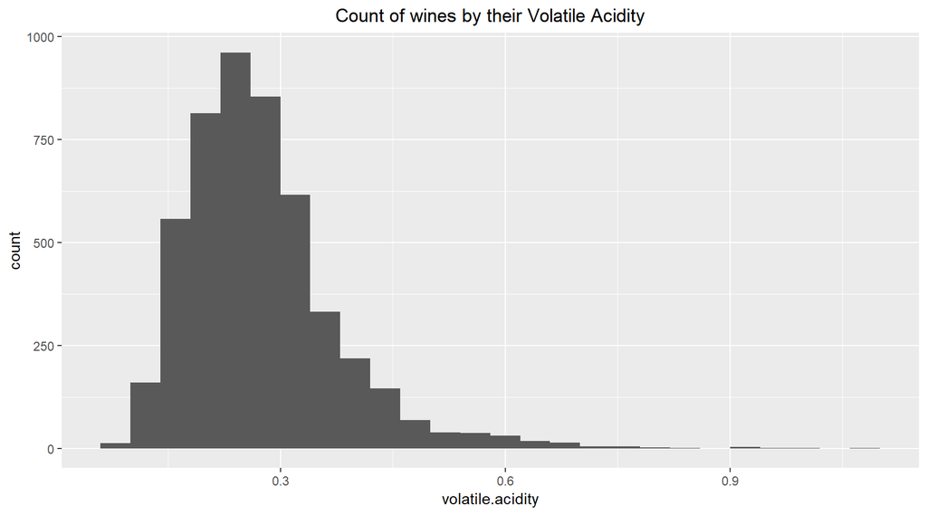

Most of the wines fall between values 0.20-0.30 of volatile acidity. It is shown that wines with higher levels of volatile acidity have an unpleasant, vinegar taste.

```
##    Min. 1st Qu.  Median    Mean 3rd Qu.    Max.
##  0.0800  0.2100  0.2600  0.2782  0.3200  1.1000
```

Let’s see if it’s reflected by the quality scores.

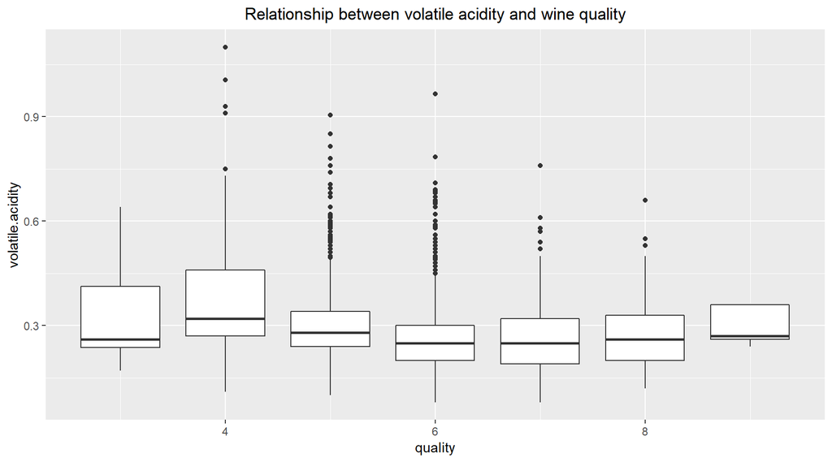

Wines with lower quality (below 7) tend to have higher volatile acidity with a lot of wines present outside of the box (having acidity higher than most of the wines with same quality score). According to a website on wine testing: “Our palates are quite sensitive to the presence of volatile acids and for that reason we try to keep their concentrations as low as possible.”

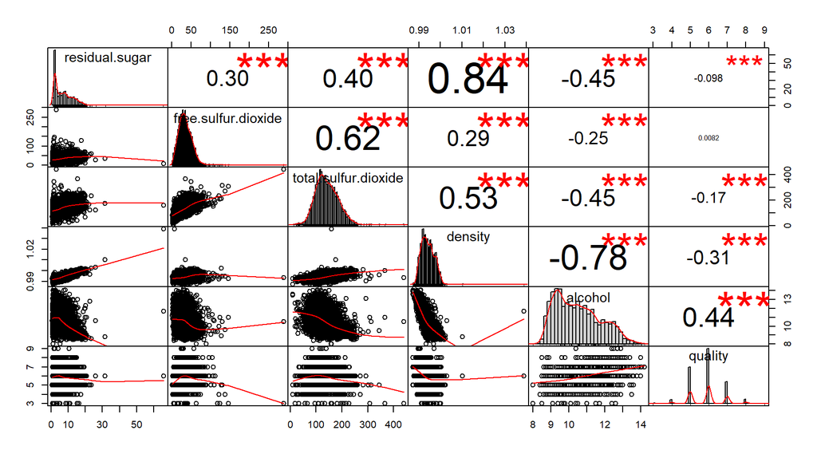

The correlation matrix of selected variables shows that the highest correlation (0.84) is between residual sugar and density which makes sense - the addition of sugar to a solution increases its density. The second highest correlation is between density and alcohol - it’s a negative correlation meaning that with the increase of density, the alcohol content decreases.

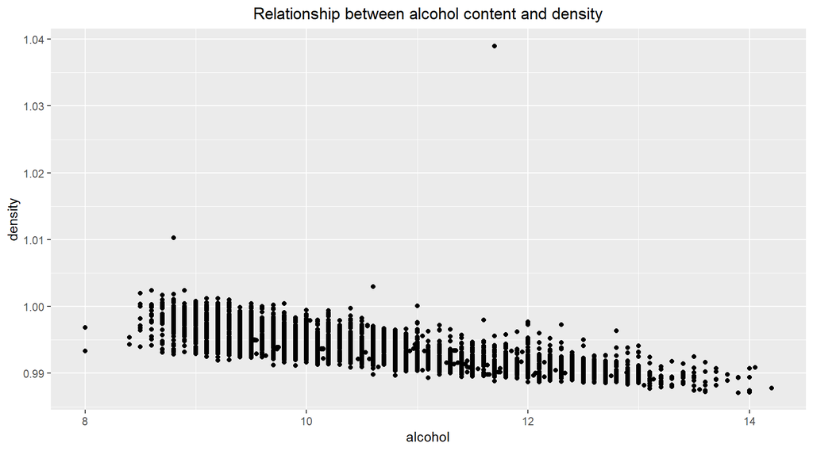

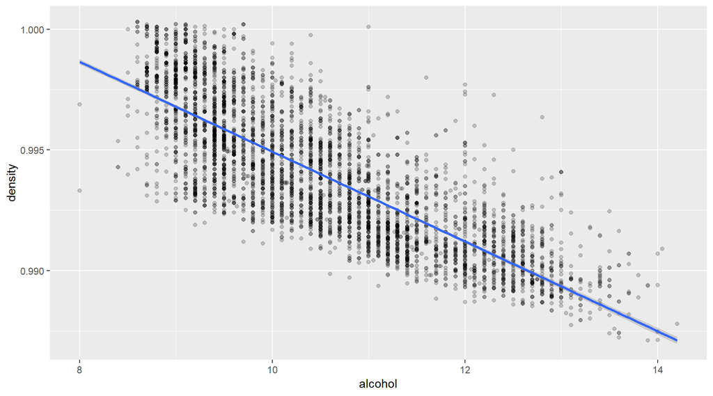

The total sulfur dioxide represents both free sulfur dioxide and fixed sulfur dioxide - it’s worth checking if the fixed sulfur dioxide has any higher correlation to any of the features.

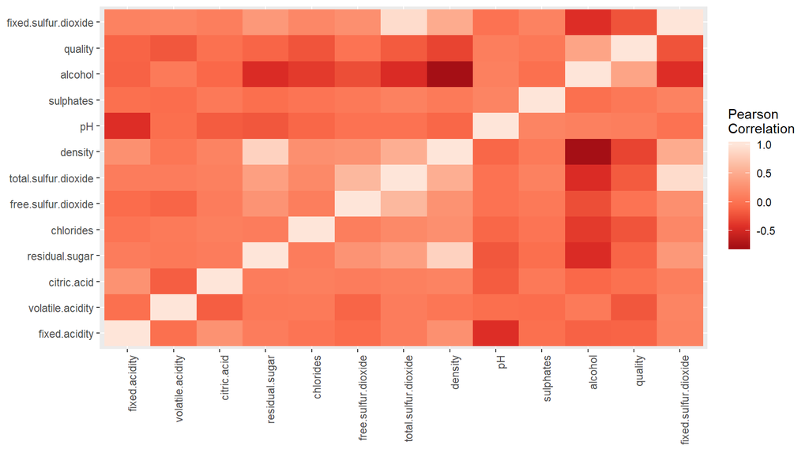

The heatmap presents correlation matrix of all features.

# Univariate Analysis

### What is the structure of your dataset?

There are 4898 white wines in the data set with 12 features (fixed acidity, volatile acidity, citric acid, residual sugar, chlorides, free sulfur dioxide, total sulfur dioxide, density, pH, sulfates, alcohol and quality). Quality is a distinct score between 0 (very bad) and 10 (very excellent).

Observations made so far:

- None of the wines in the data set have a score of 0 or 10 - they fall between values of 3 and 9 with most having a score of 6.
- Most wines have a volatile acidity between 0.2 and 0.3
- Higher scored wines have a higher alcohol content.
- Less dense wines have higher alcohol content.

### What other features in the dataset do you think will help support your investigation into your feature(s) of interest?

Alcohol seems to be most affected by residual sugar, chlorides, free sulfur dioxide, total sulfur dioxide and density - these features should be analyzed.

### Did you create any new variables from existing variables in the dataset?

I created fixed sulfur dioxide using total sulfur dioxide and free sulfur dioxide.

# Bivariate Plots Section

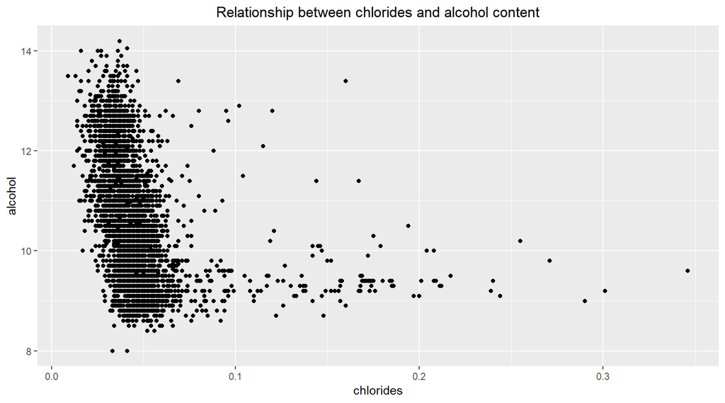

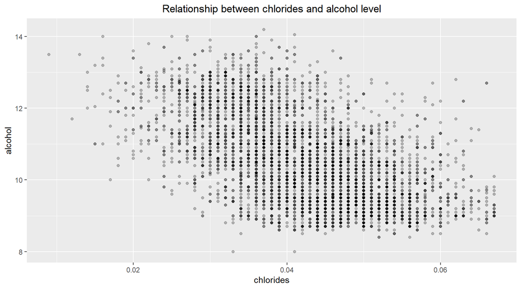

```
## [1] -0.3601887
```

The graph shows that with the increase in chlorides, the alcohol content lowers. The correlation coefficient confirms it - the correlation is negative. Wines with higher content of chlorides are expected to have lower alcohol percentage.

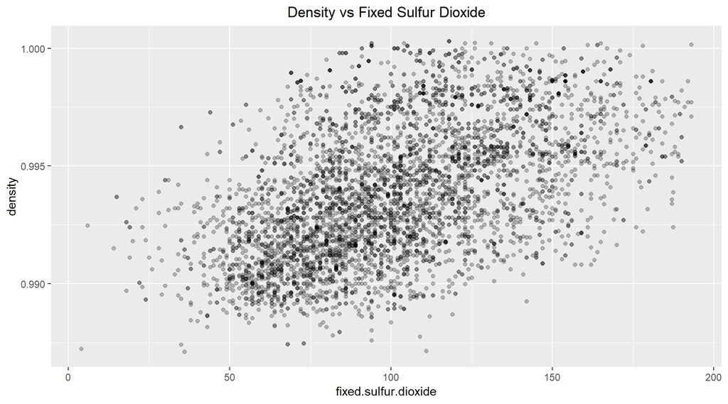

```
## [1] 0.5044469
```

With the increase of fixed sulfur dioxide levels the density increases which is proven by correlation coefficient of 0.5.

The correlation of free sulfur dioxide and density:

```
## [1] 0.2942104
```

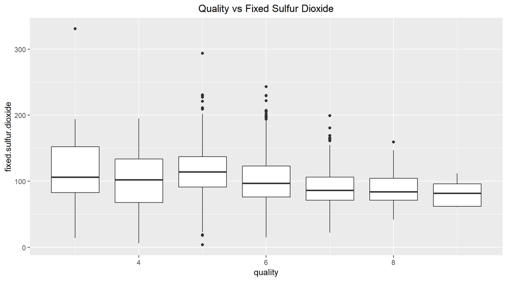

Boxplots show that wines of higher quality have less fixed sulfur dioxide than wines with lower quality. This isn’t, however, visible for free sulfur dioxide (the levels of free sulfur dioxide tend to me on the same level for most wines, no matter their quality). There is one wine with quality 3 that has over 300 mg / dm^3 of fixed sulfur dioxide and a wine of quality 5 that has almost 300 mg / dm^3. This only shows that better wines should have less sulfur dioxide in them.

```
## $`3`
##    Min. 1st Qu.  Median    Mean 3rd Qu.    Max.
##    14.0    82.5   106.0   117.3   152.2   331.0
##
## $`4`
##    Min. 1st Qu.  Median    Mean 3rd Qu.    Max.
##     6.0    67.5   102.0   101.9   133.8   195.0
##
## $`5`
##    Min. 1st Qu.  Median    Mean 3rd Qu.    Max.
##     4.0    91.0   114.0   114.5   137.0   293.5
##
## $`6`
##    Min. 1st Qu.  Median    Mean 3rd Qu.    Max.
##    15.0    76.0    97.0   101.4   123.0   243.0
##
## $`7`
##    Min. 1st Qu.  Median    Mean 3rd Qu.    Max.
##   22.00   71.00   86.00   90.99  106.00  199.00
##
## $`8`
##    Min. 1st Qu.  Median    Mean 3rd Qu.    Max.
##   42.00   71.00   84.00   89.45  104.50  159.50
##
## $`9`
##    Min. 1st Qu.  Median    Mean 3rd Qu.    Max.
##    61.0    62.0    82.0    82.6    96.0   112.0
```

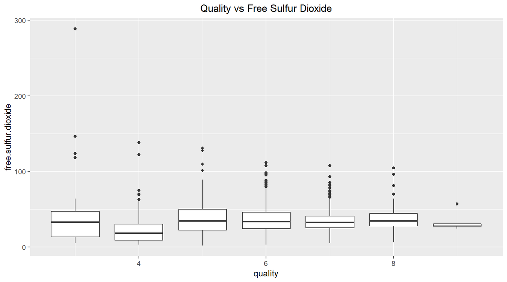

# Bivariate Analysis

- With the increase in chlorides the alcohol level lowers
- The density increases with the increase of fixed sulfur dioxide levels. It’s also true for the free sulfur dioxide but the correlation isn’t as strong.
- Higher levels of sulfur dioxide are associated with lower quality wines - too much sulfur in the wine can make the wine smell bad.

When looking at the summary of fixed sulfur dioxide for specific quality groups one can easily spot a trend - with the decrease in sulfur dioxide the quality increases. Quality 5 doesn’t seem to follow it, but other groups follow the trend. What’s interesting is that it’s not about how low we can go on sulfur levels when producing wine, as the minimum for quality 9 is way higher than any other group, but it’s about the right amount of sulfur dioxide.

### Talk about some of the relationships you observed in this part of the investigation. How did the feature(s) of interest vary with other features in the data set?

Fixed sulfur dioxide correlates with free sulfur and total sulfur dioxide which makes sense - the variable was created using them 2.

### Did you observe any interesting relationships between the other features (not the main feature(s) of interest)?

Density increases with the increase in sulfur dioxide levels which seems logical - sulfur dioxide is a dense gas so its presence causes the density to rise.

### What was the strongest relationship you found?

The strongest relationship seems to be between residual sugar and density and between alcohol and density.

# Multivariate Plots Section

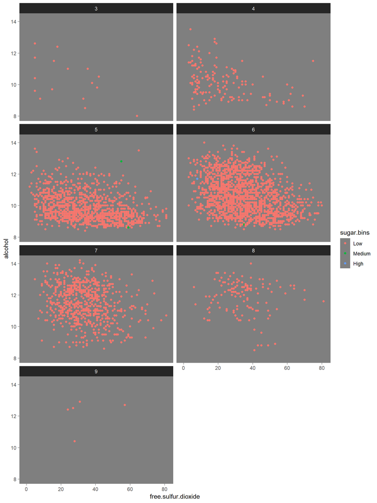

The better wines seem to have free sulfur dioxide between 20 and 60 mg / dm^3. Wines with lower rating have too little/too much sulfur dioxide. Anything above 50 mg / dm^3 can create a bad smell that affects wine rating. Not having enough sulfur dioxide in wine also isn’t good.

Wines with medium sugar levels have higher levels of free sulfur dioxide in the liquid. Most of the wines are in the first sugar bin - low sugar content.. Wines above 45 grams/liter are considered sweet and none of these wines received 9 points on quality scale. They can’t be spotted on the graph as most wines have low sugar content.

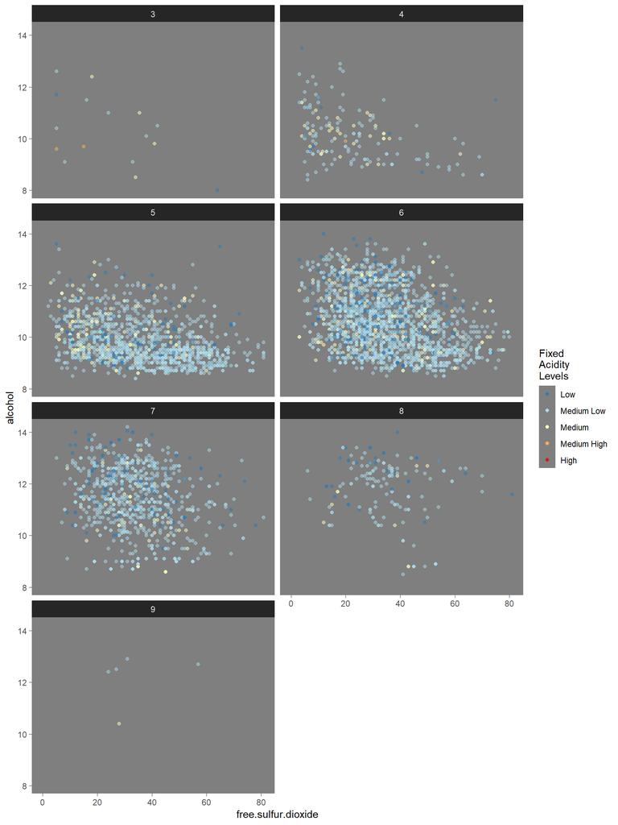

It doesn’t look like fixed acidity has any impact on any of the variables or on the wine quality. Most wines have fixed acidity between 5.5 and 9.

# Multivariate Analysis

### Talk about some of the relationships you observed in this part of the investigation. Were there features that strengthened each other in terms of looking at your feature(s) of interest?

Free sulfur dioxide and alcohol content definitely proved to have an impact on the quality of wine. Graphs proved that the right amount of sulfur dioxide in a wine can change its rating - it can’t be too low (flat taste), nor too high (bad smell). Alcohol percentage helps but can’t really help predict the quality as there are both good and bad wines with the same percentage. I would say better wines need at least 10% and the right amount of sulfur dioxide.

### Were there any interesting or surprising interactions between features?

Surprisingly, most of the wines tend to have a very low level of residual sugar - below 11.5 g/liter. Wines with higher sugar levels tend to also have higher sulfur dioxide level which doesn’t improve wine’s quality, as mentioned earlier.

# Final Plots and Summary

### Plot One

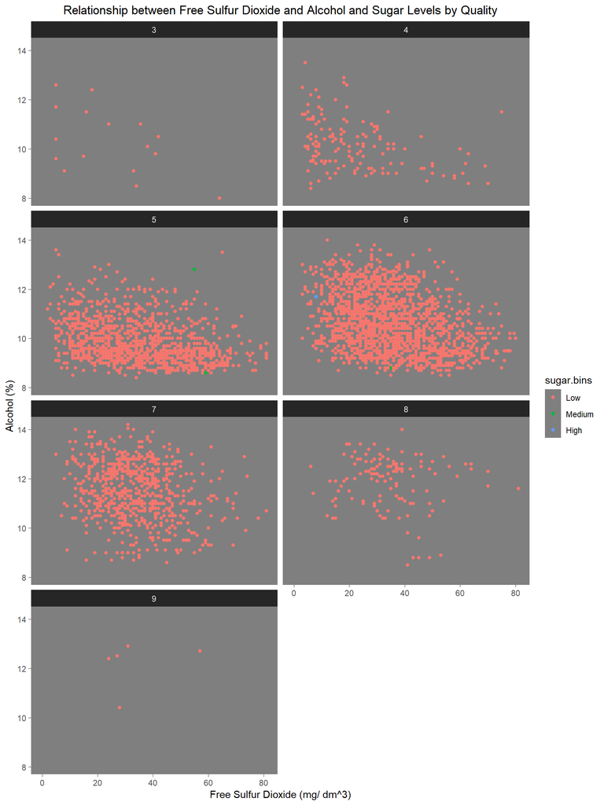

### Graph One

Represents the correlation between free sulfur dioxide, alcohol, wine quality and sugar content. I believe it perfectly illustrates that better wines have a better calculated sulfur dioxide (not too little, not too much), low levels of sugar and an alcohol content between 10 and 14%. All these 3 features must work together to create a wine that has a high rating.

### Plot Two

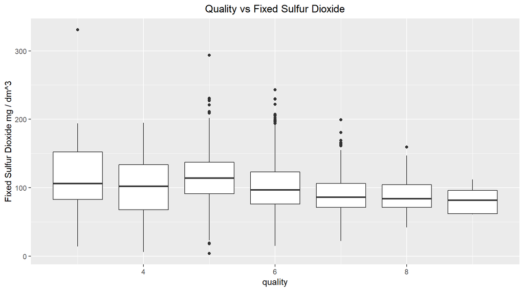

### Graph Two

This boxplot graph shows how the fixed sulfur dioxide changes across quality groups. It illustrates a downward trend, but group 5 seem to be an exception. It also proves that, even with the best wines from the dataset, sulfur dioxide is important and the goal is not to eliminate it, but to achieve a perfect balance with other chemicals. So by reading a wine label, customer shouldn’t look for lowest sulfur dioxide levels. As most of us probably wouldn’t be able to feel a difference between 100 and 110 mg / dm^3 - we should leave the wine ratings to experts.

### Plot Three

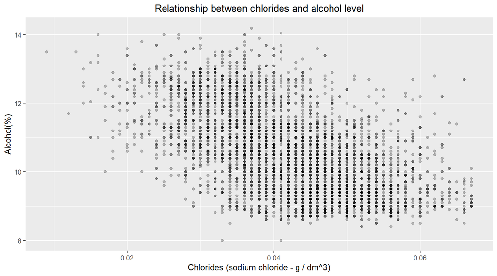

### Graph Three

This one was quite unexpected - the increase in chlorides meant a decrease in alcohol percentage. But a simple Google search shows that before any blood tests that involve chlorides a patient should avoid drinking alcohol - this proves that alcohol interferes with chloride levels (https://www.webmd.com/a-to-z-guides/what-is-a-chloride-test) .

# Reflection

The dataset wasn’t easy to work with - almost 5000 wines made it hard to read some graphs as sometimes it all looked like one big dot. Creating a project in R that I have just started learning wasn’t easy. Not only did I have to use a new programming language, I also had to use the knowledge of statistics, data interpretation, data visualization. .

In the future I would like to merge this dataset with dataset of red wines to be able to compare them and see if the chlorides or sulfur levels differ between white and red wines. It would be interesting to see what exactly causes wines that are made almost the same way to taste so differently. Having access to higher rated wines would also allow me to see if wines with rating above 9 follow the same trends with sulfur dioxide and chlorides as the ones I have analysed so far.